# A: Time series

# Water model

Singapore is planning to reduce the amount of water used by households even more by 2030, with a new target of 130 litres to be used by each person daily, or 10 litres less than the original goal.

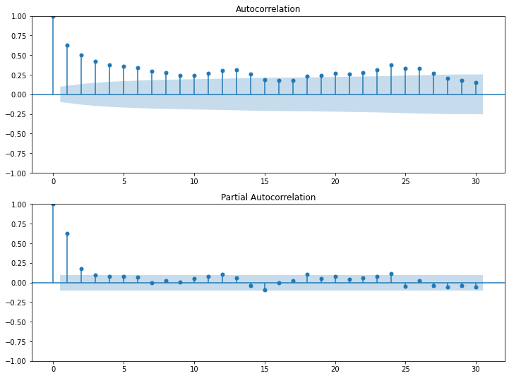

```python
#water
fig = plt.figure(figsize=(12,9))
ax1 = fig.add_subplot(211)
fig = sm.graphics.tsa.plot_acf(water, lags=30, ax=ax1)
ax2 = fig.add_subplot(212)
fig = sm.graphics.tsa.plot_pacf(water,lags=30,ax=ax2)
```

## Auto Arima

```python
#water
optimal_w = fit_auto_arima(yw_train)
```

```
Performing stepwise search to minimize aic
 ARIMA(2,0,2)(1,0,1)[12] intercept   : AIC=4029.009, Time=2.80 sec
 ARIMA(0,0,0)(0,0,0)[12] intercept   : AIC=4212.918, Time=0.07 sec
 ARIMA(1,0,0)(1,0,0)[12] intercept   : AIC=4040.744, Time=0.74 sec
 ARIMA(0,0,1)(0,0,1)[12] intercept   : AIC=4098.169, Time=0.83 sec
 ARIMA(0,0,0)(0,0,0)[12]             : AIC=5058.857, Time=0.05 sec
 ARIMA(2,0,2)(0,0,1)[12] intercept   : AIC=4029.337, Time=1.39 sec
 ARIMA(2,0,2)(1,0,0)[12] intercept   : AIC=4028.874, Time=2.71 sec
 ARIMA(2,0,2)(0,0,0)[12] intercept   : AIC=4029.687, Time=0.46 sec
 ARIMA(2,0,2)(2,0,0)[12] intercept   : AIC=4021.437, Time=5.19 sec
 ARIMA(2,0,2)(2,0,1)[12] intercept   : AIC=inf, Time=4.95 sec
 ARIMA(1,0,2)(2,0,0)[12] intercept   : AIC=4021.888, Time=3.21 sec
 ARIMA(2,0,1)(2,0,0)[12] intercept   : AIC=4024.998, Time=3.76 sec
 ARIMA(3,0,2)(2,0,0)[12] intercept   : AIC=4021.637, Time=5.97 sec
 ARIMA(2,0,3)(2,0,0)[12] intercept   : AIC=4020.158, Time=4.90 sec
 ARIMA(2,0,3)(1,0,0)[12] intercept   : AIC=4027.487, Time=2.69 sec
 ARIMA(2,0,3)(2,0,1)[12] intercept   : AIC=4021.497, Time=5.10 sec
 ARIMA(2,0,3)(1,0,1)[12] intercept   : AIC=4028.658, Time=2.99 sec
 ARIMA(1,0,3)(2,0,0)[12] intercept   : AIC=4022.403, Time=4.86 sec
 ARIMA(3,0,3)(2,0,0)[12] intercept   : AIC=4022.687, Time=6.27 sec
 ARIMA(2,0,4)(2,0,0)[12] intercept   : AIC=4021.761, Time=4.90 sec
 ARIMA(1,0,4)(2,0,0)[12] intercept   : AIC=4023.503, Time=5.09 sec
 ARIMA(3,0,4)(2,0,0)[12] intercept   : AIC=inf, Time=5.99 sec
 ARIMA(2,0,3)(2,0,0)[12]             : AIC=4025.411, Time=3.16 sec

Best model:  ARIMA(2,0,3)(2,0,0)[12] intercept
Total fit time: 78.114 seconds
                                      SARIMAX Results
===========================================================================================
Dep. Variable:                                   y   No. Observations:                  331
Model:             SARIMAX(2, 0, 3)x(2, 0, [], 12)   Log Likelihood               -2001.079
Date:                             Fri, 11 Aug 2023   AIC                           4020.158
Time:                                     23:15:43   BIC                           4054.377
Sample:                                 01-01-1990   HQIC                          4033.806
                                      - 07-01-2017
Covariance Type:                               opg
==============================================================================
                 coef    std err          z      P>|z|      [0.025      0.975]
------------------------------------------------------------------------------
intercept     91.4446     46.327      1.974      0.048       0.644     182.245
ar.L1         -0.1066      0.089     -1.201      0.230      -0.281       0.067
ar.L2          0.8628      0.080     10.752      0.000       0.706       1.020
ma.L1          0.5677      0.098      5.774      0.000       0.375       0.760
ma.L2         -0.5295      0.132     -4.003      0.000      -0.789      -0.270
ma.L3         -0.1265      0.071     -1.792      0.073      -0.265       0.012
ar.S.L12       0.0590      0.055      1.079      0.280      -0.048       0.166
ar.S.L24       0.1703      0.069      2.474      0.013       0.035       0.305
sigma2       1.05e+04    629.460     16.683      0.000    9267.672    1.17e+04
===================================================================================
Ljung-Box (L1) (Q):                   0.00   Jarque-Bera (JB):                92.69
Prob(Q):                              0.98   Prob(JB):                         0.00
Heteroskedasticity (H):               1.55   Skew:                            -0.24
Prob(H) (two-sided):                  0.02   Kurtosis:                         5.55
===================================================================================

Warnings:
[1] Covariance matrix calculated using the outer product of gradients (complex-step).
```

## Arima

```python
arima_model(yw_train, yw_valid, order=(3, 0, 0), forecast_steps=66)
```

```
                                  SARIMAX Results
====================================================================================
Dep. Variable:     Water Consumption (tons)   No. Observations:                  331
Model:                       ARIMA(3, 0, 0)   Log Likelihood               -2010.353
Date:                      Fri, 11 Aug 2023   AIC                           4030.705
Time:                              23:15:44   BIC                           4049.716
Sample:                          01-01-1990   HQIC                          4038.288
                               - 07-01-2017
Covariance Type:                        opg
==============================================================================
                 coef    std err          z      P>|z|      [0.025      0.975]
------------------------------------------------------------------------------
const        482.8294     22.991     21.001      0.000     437.769     527.890
ar.L1          0.5022      0.040     12.421      0.000       0.423       0.581
ar.L2          0.1192      0.052      2.291      0.022       0.017       0.221
ar.L3          0.1142      0.057      2.009      0.045       0.003       0.226
sigma2      1.106e+04    665.471     16.620      0.000    9755.578    1.24e+04
===================================================================================
Ljung-Box (L1) (Q):                   0.02   Jarque-Bera (JB):                83.04
Prob(Q):                              0.88   Prob(JB):                         0.00
Heteroskedasticity (H):               1.47   Skew:                            -0.12
Prob(H) (two-sided):                  0.04   Kurtosis:                         5.44
===================================================================================

Warnings:
[1] Covariance matrix calculated using the outer product of gradients (complex-step).
RMSE: 99.37351542228089
MAE: 76.73602092113929
MAPE: 17.3174331147143
```

```
<statsmodels.tsa.arima.model.ARIMAResultsWrapper at 0x23a157d32e0>
```

## SARIMA

```python
sarimax_model(yw_train, yw_valid, order=(3, 0, 0), seasonal_order=(3, 0, 0, 12), forecast_steps=66)
```

```
                                     SARIMAX Results
==========================================================================================
Dep. Variable:           Water Consumption (tons)   No. Observations:                  331
Model:             SARIMAX(3, 0, 0)x(3, 0, 0, 12)   Log Likelihood               -2020.016
Date:                            Fri, 11 Aug 2023   AIC                           4054.031
Time:                                    23:15:47   BIC                           4080.646
Sample:                                01-01-1990   HQIC                          4064.647
                                     - 07-01-2017
Covariance Type:                              opg
==============================================================================
                 coef    std err          z      P>|z|      [0.025      0.975]
------------------------------------------------------------------------------
ar.L1          0.5790      0.038     15.094      0.000       0.504       0.654
ar.L2          0.1834      0.049      3.720      0.000       0.087       0.280
ar.L3          0.2175      0.053      4.091      0.000       0.113       0.322
ar.S.L12       0.0863      0.049      1.763      0.078      -0.010       0.182
ar.S.L24       0.1567      0.070      2.231      0.026       0.019       0.294
ar.S.L36      -0.0628      0.072     -0.874      0.382      -0.204       0.078
sigma2      1.156e+04    637.817     18.124      0.000    1.03e+04    1.28e+04
===================================================================================
Ljung-Box (L1) (Q):                   0.53   Jarque-Bera (JB):               114.70
Prob(Q):                              0.47   Prob(JB):                         0.00
Heteroskedasticity (H):               1.51   Skew:                             0.14
Prob(H) (two-sided):                  0.03   Kurtosis:                         5.87
===================================================================================

Warnings:
[1] Covariance matrix calculated using the outer product of gradients (complex-step).
RMSE: 179.46458933731168
MAE: 145.73523700220719
MAPE: 28.28752519192409
```

```
<statsmodels.tsa.statespace.sarimax.SARIMAXResultsWrapper at 0x23a1582d850>
```

```python
#sarimax_model(yw_train, yw_valid, order=(2,0,1), seasonal_order=(1,0,1,12), forecast_steps=66)
```

### Best model

After tuning the hyperparameter as shown below, the AIC improved but the rmse for the walk forward validation dropped and the lags became within the 95% confidence interval. This model makes more accurate predictions on new data.

```python
wa=sarimax_model(yw_train, yw_valid, order=(2,0,1), seasonal_order=(0,1,1, 12), forecast_steps=66)
```

```
                                     SARIMAX Results
==========================================================================================
Dep. Variable:           Water Consumption (tons)   No. Observations:                  331
Model:             SARIMAX(2, 0, 1)x(0, 1, 1, 12)   Log Likelihood               -1947.776
Date:                            Fri, 11 Aug 2023   AIC                           3905.551
Time:                                    23:15:51   BIC                           3924.377
Sample:                                01-01-1990   HQIC                          3913.070
                                     - 07-01-2017
Covariance Type:                              opg
==============================================================================
                 coef    std err          z      P>|z|      [0.025      0.975]
------------------------------------------------------------------------------
ar.L1          1.2438      0.095     13.068      0.000       1.057       1.430
ar.L2         -0.2791      0.076     -3.691      0.000      -0.427      -0.131
ma.L1         -0.7952      0.080     -9.930      0.000      -0.952      -0.638
ma.S.L12      -0.8673      0.038    -22.927      0.000      -0.941      -0.793
sigma2       1.12e+04    688.567     16.263      0.000    9848.426    1.25e+04
===================================================================================
Ljung-Box (L1) (Q):                   0.00   Jarque-Bera (JB):                69.89
Prob(Q):                              0.96   Prob(JB):                         0.00
Heteroskedasticity (H):               1.54   Skew:                            -0.09
Prob(H) (two-sided):                  0.03   Kurtosis:                         5.29
===================================================================================

Warnings:
[1] Covariance matrix calculated using the outer product of gradients (complex-step).
RMSE: 99.5964650608943
MAE: 75.12760283029009
MAPE: 17.233457917304783
```

## Evaluate

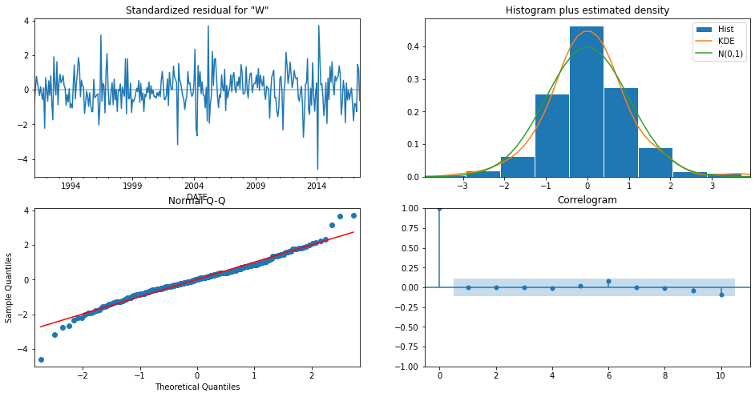

```python
wa.plot_diagnostics(figsize=(16,8))
plt.show()
```

The KDE curve is very similar to the normal distribution (labeled as N(0,1) in the plot) Normal Q-Q

Most of the data points lie on the straight line except for some scattered towards the end

Correlogram (ACF plot) 95% of correlations for lag greater than zero should not be significant. In our case, there are a no lags outside of this area

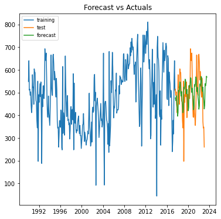

```python
extended_index = pd.date_range(start=yw_valid.index[0], periods=72,freq='MS')


fc = wa.forecast(72,alpha=0.05)

# Step 3: Convert the forecasted values to Pandas Series
fc_series = pd.Series(fc, index=extended_index)

# Step 4: Plot the results
plt.figure(figsize=(6, 6))
plt.plot(yw_train, label='training')
plt.plot(yw_valid,label='test')
plt.plot(fc_series, label='forecast')
plt.title('Forecast vs Actuals')
plt.legend(loc='upper left', fontsize=8)
plt.show()
```

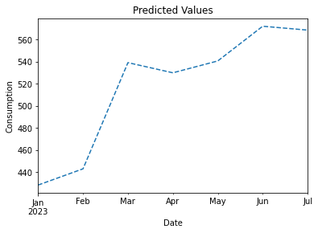

```python
df_pred = wa.predict(start='2017-08-01', end='2023-07-01')
df_pred['2023-01-01':'2023-07-01'].plot(ls='--')

# Set title, xlabel, and ylabel for the plot
plt.title('Predicted Values')
plt.xlabel('Date')
plt.ylabel('Consumption')

plt.show()
```

Water consumption is on the increasing trend with a stagnant period from March to May.

Slight drop from March to April.

```
predicted=476.658281, expected=515.300000
predicted=482.201520, expected=488.400000
predicted=500.187765, expected=503.200000
predicted=457.409118, expected=448.300000
predicted=436.361870, expected=411.700000
predicted=392.009836, expected=440.800000
predicted=435.162129, expected=579.000000
predicted=587.216407, expected=521.700000
predicted=520.862982, expected=524.400000
predicted=537.506137, expected=448.400000
predicted=526.418211, expected=604.700000
predicted=573.406510, expected=591.000000
predicted=535.039334, expected=588.000000
predicted=533.748801, expected=513.000000
predicted=531.900197, expected=465.500000
predicted=458.657965, expected=457.300000
predicted=450.864990, expected=376.500000
```

```
predicted=396.022087, expected=344.600000
predicted=416.960162, expected=550.400000
predicted=562.657294, expected=197.400000
predicted=374.203415, expected=491.000000
predicted=481.466491, expected=457.000000
predicted=514.310231, expected=501.600000
predicted=508.196734, expected=539.500000
predicted=493.505457, expected=482.100000
```

```
predicted=460.357920, expected=547.100000
predicted=510.890447, expected=390.100000
predicted=409.762214, expected=488.400000
predicted=433.744804, expected=491.700000
predicted=426.904933, expected=437.600000
predicted=472.816293, expected=529.700000
predicted=514.339901, expected=530.500000
predicted=538.360067, expected=473.500000
```

```
predicted=503.322978, expected=512.200000
predicted=558.949801, expected=693.400000
predicted=616.636061, expected=642.800000
predicted=571.391139, expected=641.400000
predicted=575.589331, expected=674.300000
```

```
predicted=593.458462, expected=569.100000
predicted=540.808800, expected=449.900000
predicted=475.164123, expected=393.000000
predicted=420.722678, expected=391.400000
```

```
predicted=479.078332, expected=485.200000
predicted=507.006367, expected=411.900000
predicted=485.627149, expected=385.500000
predicted=458.634019, expected=355.500000
predicted=496.046077, expected=427.800000
predicted=481.366197, expected=512.000000
predicted=480.591066, expected=665.700000
predicted=556.325670, expected=521.800000
predicted=493.195314, expected=495.600000
predicted=459.142520, expected=487.400000
```

```
predicted=444.780236, expected=662.800000
predicted=510.795501, expected=668.900000
predicted=605.134718, expected=627.800000
predicted=587.632881, expected=555.900000
predicted=566.228686, expected=593.100000
predicted=575.591829, expected=569.200000
predicted=625.173132, expected=504.600000
```

```
predicted=568.179488, expected=480.500000
```

```
predicted=530.928809, expected=563.200000
predicted=540.149497, expected=513.300000
predicted=513.003346, expected=373.100000
predicted=422.410738, expected=343.900000
predicted=407.446714, expected=348.300000
```

```
predicted=379.959264, expected=260.200000
Test RMSE: 89.607
```

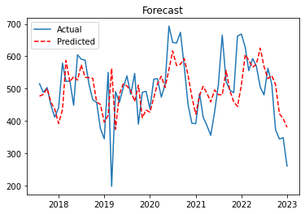

```python
walk_forecast(yw_train, yw_valid,order=(2,0,1), seasonal_order=(0,1,1, 12))
```

Predicted values follows the trend of the expected values.

# VAR

Capture dependencies and interactions between variables over time

```python
from statsmodels.tsa.stattools import grangercausalitytests
#determines whether one time series is useful in forecasting another
def grangers_causation_matrix(data, variables, test='ssr_chi2test', verbose=False):
    df = pd.DataFrame(np.zeros((len(variables), len(variables))), columns=variables, index=variables)
    for c in df.columns:
        for r in df.index:
            test_result = grangercausalitytests(data[[r, c]], maxlag=12, verbose=False)
            p_values = [round(test_result[i+1][0][test][1],4) for i in range(12)]
            if verbose: print(f'Y = {r}, X = {c}, P Values = {p_values}')
            min_p_value = np.min(p_values)
            df.loc[r, c] = min_p_value
    df.columns = [var + '_x' for var in variables]
    df.index = [var + '_y' for var in variables]
    return df
```

```python
grangers_causation_matrix(df.iloc[:, :3], variables = df.iloc[:, :3].columns)
```

|  | Gas Consumption (tons)_x | Electricity Consumption (MWh)_x | Water Consumption (tons)_x |
| --- | --- | --- | --- |
| Gas Consumption (tons)_y | 1.0000 | 0.3018 | 0.2368 |
| Electricity Consumption (MWh)_y | 0.1018 | 1.0000 | 0.1045 |
| Water Consumption (tons)_y | 0.0335 | 0.0131 | 1.0000 |

P-value for Gas Consumption (tons)_x and Water Consumption (tons)_y, Electricity Consumption (MWh)_x and Water Consumption (tons)_y is less than 0.05.

Hence we reject the null hypothesis and conclude that Gas consumption affects water consumption and electricity consumption affects water consumption

```python
granger_1 = grangercausalitytests(df[['Water Consumption (tons)','Electricity Consumption (MWh)']], 10)
```

```
Granger Causality
number of lags (no zero) 1
ssr based F test:         F=6.1114  , p=0.0139  , df_denom=393, df_num=1
ssr based chi2 test:   chi2=6.1580  , p=0.0131  , df=1
likelihood ratio test: chi2=6.1107  , p=0.0134  , df=1
parameter F test:         F=6.1114  , p=0.0139  , df_denom=393, df_num=1

Granger Causality
number of lags (no zero) 2
ssr based F test:         F=2.7252  , p=0.0668  , df_denom=390, df_num=2
ssr based chi2 test:   chi2=5.5203  , p=0.0633  , df=2
likelihood ratio test: chi2=5.4820  , p=0.0645  , df=2
parameter F test:         F=2.7252  , p=0.0668  , df_denom=390, df_num=2

Granger Causality
number of lags (no zero) 3
ssr based F test:         F=1.6509  , p=0.1772  , df_denom=387, df_num=3
ssr based chi2 test:   chi2=5.0424  , p=0.1687  , df=3
likelihood ratio test: chi2=5.0104  , p=0.1710  , df=3
parameter F test:         F=1.6509  , p=0.1772  , df_denom=387, df_num=3

Granger Causality
number of lags (no zero) 4
ssr based F test:         F=1.1031  , p=0.3547  , df_denom=384, df_num=4
ssr based chi2 test:   chi2=4.5160  , p=0.3407  , df=4
likelihood ratio test: chi2=4.4902  , p=0.3437  , df=4
parameter F test:         F=1.1031  , p=0.3547  , df_denom=384, df_num=4

Granger Causality
number of lags (no zero) 5
ssr based F test:         F=1.0502  , p=0.3878  , df_denom=381, df_num=5
ssr based chi2 test:   chi2=5.4025  , p=0.3688  , df=5
likelihood ratio test: chi2=5.3656  , p=0.3729  , df=5
parameter F test:         F=1.0502  , p=0.3878  , df_denom=381, df_num=5

Granger Causality
number of lags (no zero) 6
ssr based F test:         F=0.8427  , p=0.5375  , df_denom=378, df_num=6
ssr based chi2 test:   chi2=5.2303  , p=0.5146  , df=6
likelihood ratio test: chi2=5.1956  , p=0.5190  , df=6
```

[output cut: 14 more lines]

```
parameter F test:         F=1.0095  , p=0.4282  , df_denom=372, df_num=8

Granger Causality
number of lags (no zero) 9
ssr based F test:         F=1.0230  , p=0.4209  , df_denom=369, df_num=9
ssr based chi2 test:   chi2=9.6809  , p=0.3769  , df=9
likelihood ratio test: chi2=9.5621  , p=0.3871  , df=9
parameter F test:         F=1.0230  , p=0.4209  , df_denom=369, df_num=9

Granger Causality
number of lags (no zero) 10
ssr based F test:         F=1.1573  , p=0.3186  , df_denom=366, df_num=10
ssr based chi2 test:   chi2=12.2371 , p=0.2695  , df=10
likelihood ratio test: chi2=12.0476 , p=0.2819  , df=10
parameter F test:         F=1.1573  , p=0.3186  , df_denom=366, df_num=10
```

```python
macro_data = df[['Water Consumption (tons)','Gas Consumption (tons)']]
```

```python
train_df=macro_data[:-12]
test_df=macro_data[-12:]
```

```python
from statsmodels.tsa.statespace.varmax import VARMAX
from statsmodels.tsa.api import VAR
model = VAR(train_df.diff()[1:])
sorted_order=model.select_order(maxlags=20)
print(sorted_order.summary())
```

```
 VAR Order Selection (* highlights the minimums)
==================================================
       AIC         BIC         FPE         HQIC
--------------------------------------------------
0        12.15       12.17   1.885e+05       12.16
1        11.95       12.02   1.553e+05       11.98
2        11.91      12.02*   1.485e+05       11.95
3        11.87       12.02   1.433e+05       11.93
4        11.85       12.04   1.402e+05      11.93*
5        11.84       12.07   1.382e+05       11.93
6        11.83       12.11   1.375e+05       11.94
7        11.85       12.17   1.396e+05       11.97
8        11.83       12.19   1.374e+05       11.97
9       11.83*       12.24  1.371e+05*       11.99
10       11.83       12.28   1.377e+05       12.01
11       11.84       12.33   1.386e+05       12.03
12       11.83       12.36   1.372e+05       12.04
13       11.84       12.42   1.385e+05       12.07
14       11.85       12.47   1.396e+05       12.09
15       11.85       12.52   1.406e+05       12.12
16       11.85       12.55   1.398e+05       12.13
17       11.85       12.60   1.398e+05       12.14
18       11.85       12.64   1.406e+05       12.17
19       11.85       12.68   1.397e+05       12.18
20       11.86       12.74   1.418e+05       12.21
--------------------------------------------------
```

```python
from statsmodels.tsa.statespace.varmax import VARMAX

var_model = VARMAX(train_df, order=(2,0),enforce_stationarity= True)
fitted_model = var_model.fit(disp=False)
print(fitted_model.summary())
```

```
                                             Statespace Model Results
==================================================================================================================
Dep. Variable:     ['Water Consumption (tons)', 'Gas Consumption (tons)']   No. Observations:                  385
Model:                                                             VAR(2)   Log Likelihood               -3328.090
                                                              + intercept   AIC                           6682.179
Date:                                                    Fri, 11 Aug 2023   BIC                           6733.571
Time:                                                            23:19:43   HQIC                          6702.561
Sample:                                                        01-01-1990
                                                             - 01-01-2022
Covariance Type:                                                      opg
===================================================================================
Ljung-Box (L1) (Q):             0.18, 0.01   Jarque-Bera (JB):        70.14, 884.61
Prob(Q):                        0.67, 0.92   Prob(JB):                   0.00, 0.00
Heteroskedasticity (H):         1.52, 2.32   Skew:                      -0.14, 0.27
Prob(H) (two-sided):            0.02, 0.00   Kurtosis:                  5.07, 10.41
                         Results for equation Water Consumption (tons)
===============================================================================================
                                  coef    std err          z      P>|z|      [0.025      0.975]
-----------------------------------------------------------------------------------------------
intercept                     129.5436     44.399      2.918      0.004      42.523     216.565
L1.Water Consumption (tons)     0.5721      0.047     12.156      0.000       0.480       0.664
L1.Gas Consumption (tons)       4.0630      1.255      3.237      0.001       1.603       6.523
L2.Water Consumption (tons)     0.1364      0.051      2.683      0.007       0.037       0.236
L2.Gas Consumption (tons)      -3.5343      1.270     -2.783      0.005      -6.024      -1.045
                          Results for equation Gas Consumption (tons)
===============================================================================================
                                  coef    std err          z      P>|z|      [0.025      0.975]
-----------------------------------------------------------------------------------------------
intercept                       7.1986      1.712      4.206      0.000       3.844      10.553
L1.Water Consumption (tons)    -0.0003      0.002     -0.167      0.868      -0.004       0.003
L1.Gas Consumption (tons)       0.5474      0.040     13.715      0.000       0.469       0.626
L2.Water Consumption (tons)    -0.0009      0.002     -0.493      0.622      -0.004       0.003
L2.Gas Consumption (tons)       0.1721      0.048      3.566      0.000       0.078       0.267
                                                  Error covariance matrix
============================================================================================================================
                                                               coef    std err          z      P>|z|      [0.025      0.975]
----------------------------------------------------------------------------------------------------------------------------
sqrt.var.Water Consumption (tons)                          102.9257      3.346     30.764      0.000      96.368     109.483
sqrt.cov.Water Consumption (tons).Gas Consumption (tons)    -1.4460      0.133    -10.851      0.000      -1.707      -1.185
sqrt.var.Gas Consumption (tons)                              3.2422      0.086     37.738      0.000       3.074       3.411
============================================================================================================================

Warnings:
[1] Covariance matrix calculated using the outer product of gradients (complex-step).
```

AIC fairs poorly, therefore we did not choose the vector autoregressive model. May be due to moderate not strong enough correlation between the variables.